# Sinais

Um sinal é um conjunto de dados descrevendo um fenômeno físico, como um sinal de áudio ou de comunicação, e são parametrizados em função de uma ou mais variáveis independentes. Em sinais contínuos na análise de sistemas lineares o tempo $t$ é normalmente a variável independente. Quando um intervalo de tempo é dividido em intervalos discretos $nT_s$ onde $n$ é um número inteiro e $T_s$ é o intervalo entre amostras, a variável independente é $n$.

## Classificação de Sinais

- Quando um sinal é repetido em intervalos regulares $T$ de tempo, o sinal é dito periódico com período $T$. O menor valor de $T$ para o qual a repetição do sinal ocorre é chamado de período fundamental $T_0$. Como exemplo, a senoide $\cos(\omega t)$ é um sinal que se repete com período $k \frac{2\pi}{\omega}$ onde $k$ é um valor inteiro, ou seja o sinal é repetido após qualquer múltiplo de $\frac{2\pi}{\omega}$, e este último é o período fundamental $T_0$. Sinais que não se repetem com períodos definidos são ditos não periódicos.
- Um sinal especificado para valores contínuos de tempo é um sinal contínuo no tempo. Um exemplo de um sinal contínuo no tempo é o sinal decrito pela função $A\cos(\omega t)$ que decreve um sinal de amplitude $A$, oscilando periodicamente com frequência angular $\omega=2\pi f$.

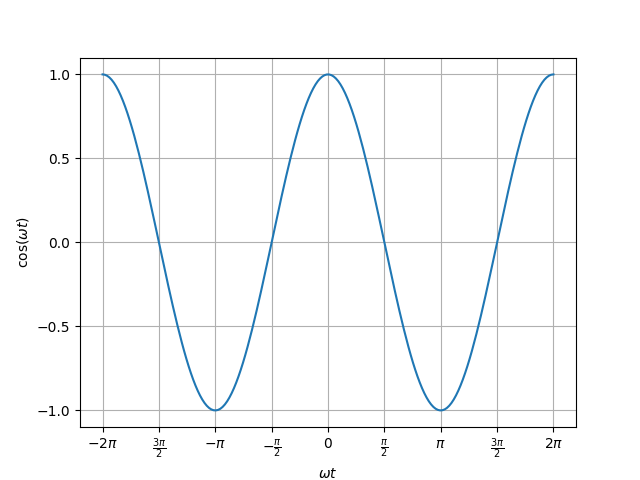

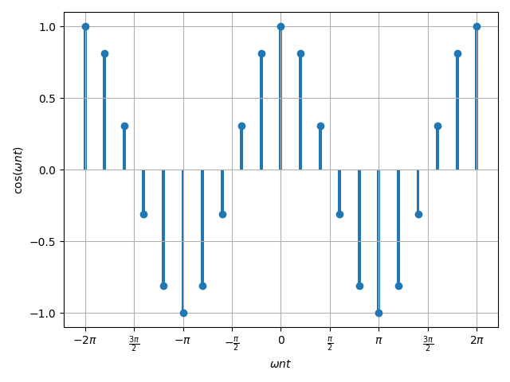

- Um sinal cuja amplitude pode assumir qualquer valor em uma faixa contínua é um sinal analógico. Um sinal analógico pode assumir um número infinito de valores.
- Um sinal cujas amplitudes podem ter apenas um número finito de valores é um sinal digital. Por exemplo, um sinal armazenado em um registrador de 3 bits pode assumir $ 2^3=8$ valores distintos.

É importante que sinais analógicos não sejam confundidos com sinais contínuos, assim como sinais discretos não sejam confundidos com sinais digitais. Ao realizar a amostragem de um sinal de áudio, por exemplo, o amostrador registra o nível do sinal em cada instante de amostragem, e o resultado é um sinal representado por um conjunto discreto de valores. O sinal entretanto, ainda é um sinal analógico, e a conversão para o domínio digital ocorrerá apenas quando os valores assumirem níveis discretos em uma escala de $ M$ valores possíveis.

## Algumas Operações Envolvendo Sinais

### Deslocamento no Tempo

Seja um sinal $x(t)$ e uma cópia deste atrasada no tempo por $T$ segundos. A cópia atrasada sera descrita por $x(t-T)$, assim como sua cópia adiantada pelo mesmo intervalo será descrita por $x(t+T)$ (ver figuras abaixo para $T=5$).

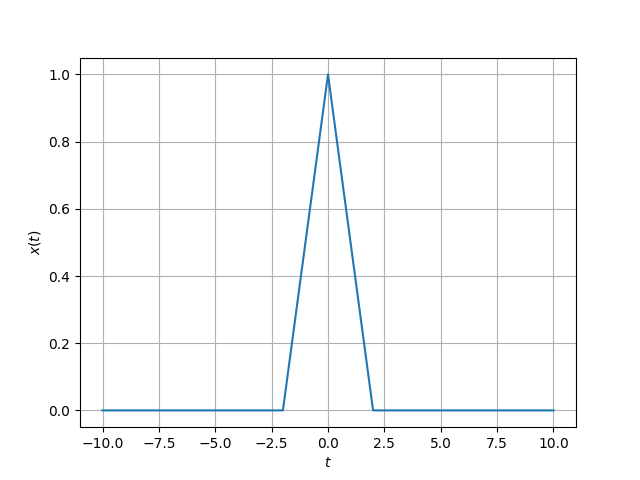

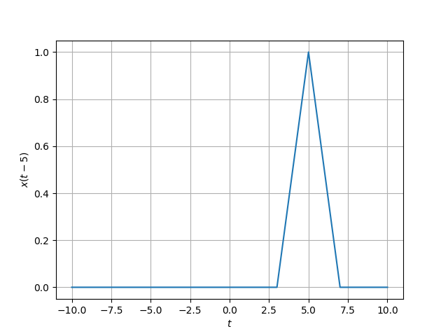

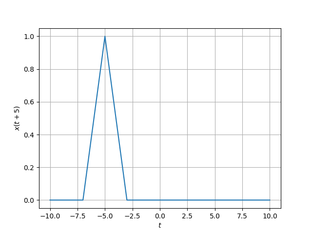

### Escalonamento no Tempo

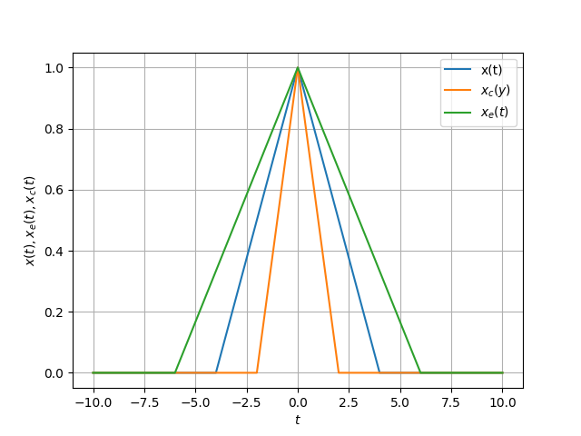

- Reversão no tempo: Um sinal $x(t)$ será reverso no tempo se houver uma rotação de $180^o$ em torno do eixo verical, ou seja, se $x_r(t)=x(-t)$. As próximas duas figuras ilustram um exemplo para um sinal $x(t)$ e sua cópia reversa $x_r(t)$.

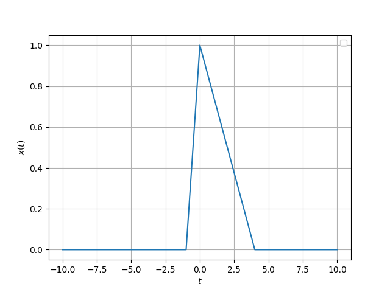

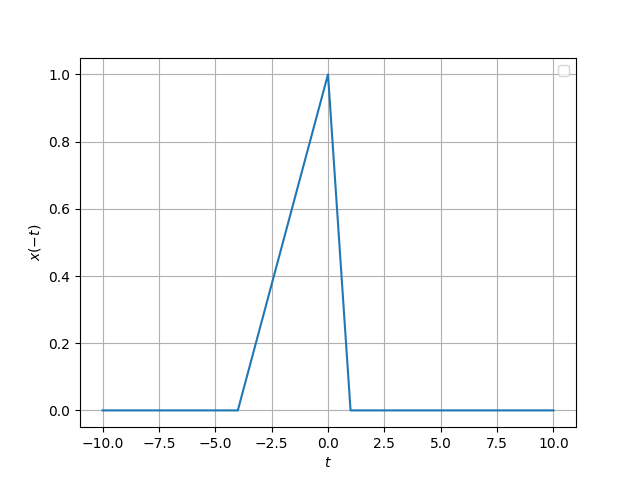

## Alguns Sinais Importantes em Sistemas Lineares

### A Função Degrau Unitário ou Função Passo de Heaviside

Na descrição matemática de sistemas físicos frequentemente é necessário modelar-se um processo existente a partir de um instante inicial. Por exemplo, em um circuito elétrico uma fonte de tensão senoidal é acoplada à rede no instante $t=0$. Isto pode ser realizado utilizando-se uma função definida como:

$$ \begin{equation*} u(t):= \begin{cases}0\;\;\forall \; t\; \lt 0\\1\;\;\forall \;t\; \gt 0\end{cases} \end{equation*}$$

de forma que se $V(t)$ é uma fonte de tensão senoidal, então $V(t)u(t)$ representa a fonte aplicada em $t=0$. A função degrau unitário é mostrada na figura abaixo:

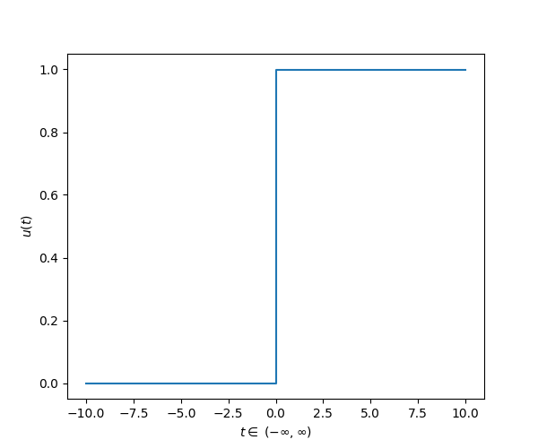

O degrau unitário pode ser usado para descrição de outras funções definidas por intervalos, como por exemplo, um pulso de amplitude unitária entre os instantes $t=0\;s$ e $t=5\;s$ pode ser convenientemente descrito como $u(t)-u(t-5)$, como mostrado na próxima figura:

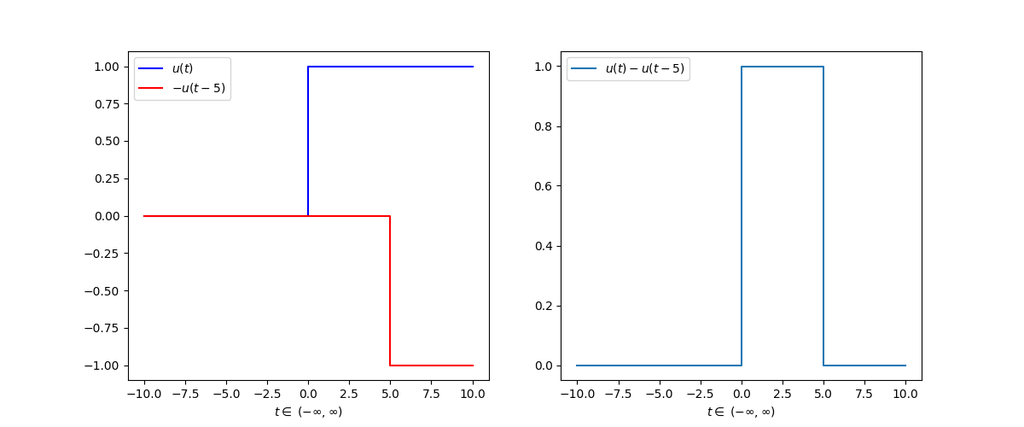

### O Impulso Unitário, ou Delta de Dirac

O Impulso unitário $ \delta (t)$ é uma "função" muito importante parta o estudo de sistemas físicos em geral, e foi definida por Paul Dirac como:

$$ \begin{equation*} \delta(t):= \begin{cases}\delta(t)=0\;\;\forall t \neq 0\\\int_{-\infty}^{\infty}\delta(t)dt\;=\;1\end{cases} \end{equation*}$$

e intuitivamente representa um impulso (força, ou carga) aplicado no instante $ t=0$. É importante notar que o impulso não é, ele próprio, definido neste instante, ele é nulo para todo $t\ne 0$ e seu valor médio é 1, de onde deriva o seu nome. Por isso, o impulso unitário não pode ser considerado como uma função, no sentido próprio do termo, mas ele é claramente o limite de uma sequência de funções pulso ou triangulares (ou outras dunções tais como o pulso gaussiano) cuja base tenda para zero e mantenha sua área com valor constante unitário (ver figura abaixo). Na figura, a função triangular $\Delta(t)$ é definida de tal forma que sua base tem comprimento $2\epsilon$ e sua altura seja igual a $ \frac{1}{\epsilon}$, de forma que sua área total seja sempre unitária. Quando $\epsilon \rightarrow 0$, a amplitude da função triangular cresce rapidamente pois $\frac{1}{\epsilon}\rightarrow \infty$.

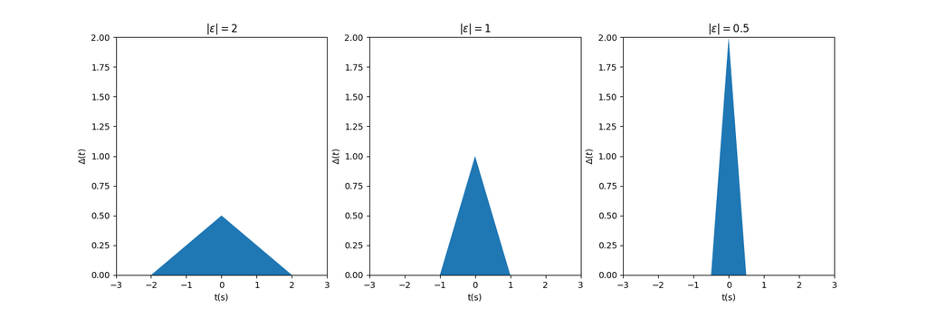

Aqui usamos uma biblioteca, lcapy, para plotar um impulso.

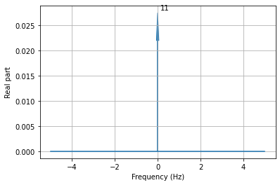

```python
from matplotlib.pyplot import savefig
from lcapy import *

nexpr(1).DTFT().remove_images((-5, 5)).subs(dt, 1).plot((-5, 5));
```

Algumas propriedades do Impulso são muito importantes e possuem muitas aplicações no estudo de sistemas lineares:

- Propriedade da amostragem: multiplicando o impulso por uma função $\phi (t)$ contínua em $t=0$ e lembrando que o impulso é nulo para $ t\ne 0$,

$$\begin{equation*} \phi(t)\delta(t)=\phi(0)\delta(t)\;, \end{equation*}$$

e portanto, integrando de $-\infty$ a $\infty$,

$$ \begin{equation*} \int_{-\infty}^{\infty}\phi(t)\delta(t)dt\;=\;\phi(0)\int_{-\infty}^{\infty}\delta(t)dt\;=\;\phi(0). \end{equation*}$$

Portanto, a área do produto de uma função com um impulso $\delta(t)$ é igual ao valor dessa função no instante em que o impulso unitário está localizado.

- Considerado como uma Função Generalizada, o impulso é a própria derivada da função degrau unitário, pois, tomando-se a integral por partes da derivada de uma função contínua obtem-se a mesma propriedade da amostragem acima, ou seja

$$\begin{equation*} \int_{-\infty}^{\infty}\frac{du}{dt}\phi(t)dt=u(t)\phi(t)\biggr|_{-\infty}^{\,\infty}-\int_{-\infty}^{\infty}u(t)\frac{d\phi(t)}{dt}dt=\phi(0), \end{equation*} $$

,

ou seja, a derivada do degrau opera sobre $\phi(t)$ exatamente como $\delta(t)$,

$$\begin{equation*} \frac{du}{dt}=\delta(t) \end{equation*}$$

### A Função Exponencial

Finalmente, outra função muito importante em teoria de sistemas lineares é a função exponencial $e^{st}$, onde $s$ é , no caso geral, uma varável complexa, $s=\sigma +j\omega $. Portanto, pode-se escrever, usando a identidade de Euler,

$$e^{st}=e^{\sigma t}e^{j\omega t} =e^{\sigma t}(\cos \omega t + j\sin \omega t),$$

da qual tomando a parte real resulta $e^{\sigma t}\cos \omega t $ ou seja, uma função senoidal com amplitude constante quando $\sigma = 0$, uma função exponencial pura (crescente ou decrescente) quando $\omega=0$, ou finalmente uma senoide com amplitude crescente ou decrescente, com frequência $\omega$ e $\sigma \gt 0 \;\mbox{ou} \;\sigma \lt 0$, respectivamente.

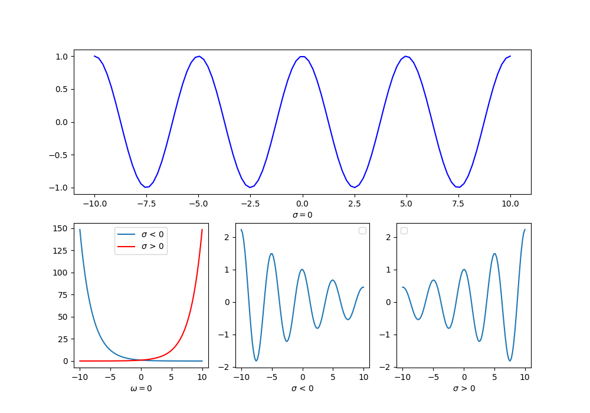